# README

## Overview

This is a non-parametric [local regression](https://en.wikipedia.org/wiki/Local_regression) graph for the Wikipedia page [“Opinion polling for the 46th Canadian federal election”, specifically the section “Government approval”](https://en.wikipedia.org/wiki/Opinion_polling_for_the_46th_Canadian_federal_election#Government_approval_polls).

**Current version:**

[figure not shown]

## Acknowledgements

Based off of [this person’s](https://en.wikipedia.org/wiki/User:Gbuvn) [code on GitLab](https://gitlab.com/gbuvn1/opinion-polling-graph), which was used for LOESS regressions of election polls (from polling firms such as Abacus Data, Léger, and Ipsos) on Wikipedia, such as this one.

The previous graph (as seen below) was made by Wikipedia user ST2407 but stopped being updated for a long time and was [removed by them](https://en.wikipedia.org/w/index.php?title=Opinion_polling_for_the_46th_Canadian_federal_election&diff=prev&oldid=1360141768) from Wikipedia.

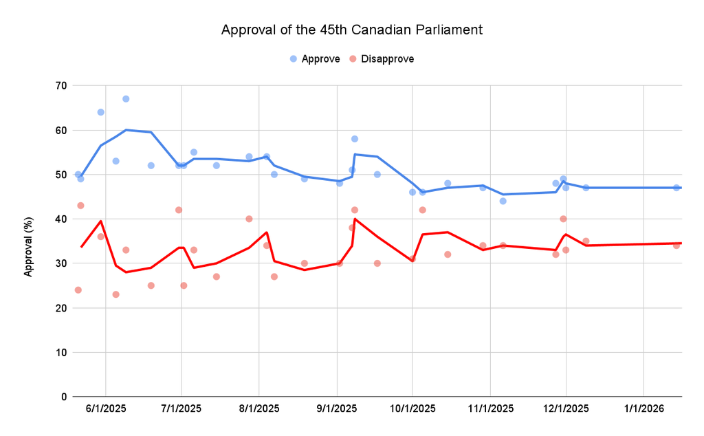

## Automated CSV Updates

`update_polls.py` checks the Wikipedia page’s “Table of polls” section daily for new government approval polls, parses the wikitext directly (rather than scraping rendered HTML), and appends any new rows to `carney government approval polls.csv`, skipping firms listed in `Which polling firms to inlcude.md`. This runs via a scheduled GitHub Actions workflow, which also re-renders the LOESS plot and opens a GitHub issue summarizing any new polls when the CSV changes. I will also try to update the original Wikipedia table with new polls. A future project could be to scrape new polls directly from the pollters websites.